# Topic 9: Correspondence Analysis (CA)

Prof. AJ Smit

# Correspondence Analysis

## Set-up the analysis environment

```r
library(tidyverse)
library(vegan)
```

## The Doubs River data

This time we work with the species data:

```r
spe <- read.csv("Num_Ecol_R_book_ed1/DoubsSpe.csv")
spe <- dplyr::select(spe, -1)
spe
```

| Cogo | Satr | Phph | Babl | Thth | Teso | Chna | Pato | Lele | Sqce | Baba | Albi | Gogo | Eslu | Pefl | Rham | Legi | Scer | Cyca | Titi | Abbr | Icme | Gyce | Ruru | Blbj | Alal | Anan |
| --- | --- | --- | --- | --- | --- | --- | --- | --- | --- | --- | --- | --- | --- | --- | --- | --- | --- | --- | --- | --- | --- | --- | --- | --- | --- | --- |
| 0 | 3 | 0 | 0 | 0 | 0 | 0 | 0 | 0 | 0 | 0 | 0 | 0 | 0 | 0 | 0 | 0 | 0 | 0 | 0 | 0 | 0 | 0 | 0 | 0 | 0 | 0 |
| 0 | 5 | 4 | 3 | 0 | 0 | 0 | 0 | 0 | 0 | 0 | 0 | 0 | 0 | 0 | 0 | 0 | 0 | 0 | 0 | 0 | 0 | 0 | 0 | 0 | 0 | 0 |
| 0 | 5 | 5 | 5 | 0 | 0 | 0 | 0 | 0 | 0 | 0 | 0 | 0 | 1 | 0 | 0 | 0 | 0 | 0 | 0 | 0 | 0 | 0 | 0 | 0 | 0 | 0 |
| 0 | 4 | 5 | 5 | 0 | 0 | 0 | 0 | 0 | 1 | 0 | 0 | 1 | 2 | 2 | 0 | 0 | 0 | 0 | 1 | 0 | 0 | 0 | 0 | 0 | 0 | 0 |
| 0 | 2 | 3 | 2 | 0 | 0 | 0 | 0 | 5 | 2 | 0 | 0 | 2 | 4 | 4 | 0 | 0 | 2 | 0 | 3 | 0 | 0 | 0 | 5 | 0 | 0 | 0 |
| 0 | 3 | 4 | 5 | 0 | 0 | 0 | 0 | 1 | 2 | 0 | 0 | 1 | 1 | 1 | 0 | 0 | 0 | 0 | 2 | 0 | 0 | 0 | 1 | 0 | 0 | 0 |
| 0 | 5 | 4 | 5 | 0 | 0 | 0 | 0 | 1 | 1 | 0 | 0 | 0 | 0 | 0 | 0 | 0 | 0 | 0 | 0 | 0 | 0 | 0 | 0 | 0 | 0 | 0 |
| 0 | 0 | 0 | 0 | 0 | 0 | 0 | 0 | 0 | 0 | 0 | 0 | 0 | 0 | 0 | 0 | 0 | 0 | 0 | 0 | 0 | 0 | 0 | 0 | 0 | 0 | 0 |
| 0 | 0 | 1 | 3 | 0 | 0 | 0 | 0 | 0 | 5 | 0 | 0 | 0 | 0 | 0 | 0 | 0 | 0 | 0 | 1 | 0 | 0 | 0 | 4 | 0 | 0 | 0 |
| 0 | 1 | 4 | 4 | 0 | 0 | 0 | 0 | 2 | 2 | 0 | 0 | 1 | 0 | 0 | 0 | 0 | 0 | 0 | 0 | 0 | 0 | 0 | 0 | 0 | 0 | 0 |

[output cut: 20 more lines]

## Do the CA

The **vegan** function `cca()` can be used for CA and Constrained Correspondence Analysis (CCA). When we do not specify constraints, as we do here, we will do a simple CA:

```r
spe_ca <- cca(X = spe)
```

```
Error in cca.default(X = spe) :
  all row sums must be >0 in the community data matrix
```

Okay, so there’s a problem. The error message says that at least one of the rows sums to 0. Which one?

```r
apply(spe, 1, sum)
```

```
 [1]  3 12 16 21 34 21 16  0 14 14 11 18 19 28 33 40 44 42 46 56 62 72  4 15 11 43 63 70 87 89
```

We see that the offending row is row 8, so we can omit it. This function will omit any row that sums to zero (or less):

```r
spe <- spe[rowSums(spe[]) > 0, ]
spe
```

|  | Cogo | Satr | Phph | Babl | Thth | Teso | Chna | Pato | Lele | Sqce | Baba | Albi | Gogo | Eslu | Pefl | Rham | Legi | Scer | Cyca | Titi | Abbr | Icme | Gyce | Ruru | Blbj | Alal | Anan |
| --- | --- | --- | --- | --- | --- | --- | --- | --- | --- | --- | --- | --- | --- | --- | --- | --- | --- | --- | --- | --- | --- | --- | --- | --- | --- | --- | --- |
| 1 | 0 | 3 | 0 | 0 | 0 | 0 | 0 | 0 | 0 | 0 | 0 | 0 | 0 | 0 | 0 | 0 | 0 | 0 | 0 | 0 | 0 | 0 | 0 | 0 | 0 | 0 | 0 |
| 2 | 0 | 5 | 4 | 3 | 0 | 0 | 0 | 0 | 0 | 0 | 0 | 0 | 0 | 0 | 0 | 0 | 0 | 0 | 0 | 0 | 0 | 0 | 0 | 0 | 0 | 0 | 0 |
| 3 | 0 | 5 | 5 | 5 | 0 | 0 | 0 | 0 | 0 | 0 | 0 | 0 | 0 | 1 | 0 | 0 | 0 | 0 | 0 | 0 | 0 | 0 | 0 | 0 | 0 | 0 | 0 |
| 4 | 0 | 4 | 5 | 5 | 0 | 0 | 0 | 0 | 0 | 1 | 0 | 0 | 1 | 2 | 2 | 0 | 0 | 0 | 0 | 1 | 0 | 0 | 0 | 0 | 0 | 0 | 0 |
| 5 | 0 | 2 | 3 | 2 | 0 | 0 | 0 | 0 | 5 | 2 | 0 | 0 | 2 | 4 | 4 | 0 | 0 | 2 | 0 | 3 | 0 | 0 | 0 | 5 | 0 | 0 | 0 |
| 6 | 0 | 3 | 4 | 5 | 0 | 0 | 0 | 0 | 1 | 2 | 0 | 0 | 1 | 1 | 1 | 0 | 0 | 0 | 0 | 2 | 0 | 0 | 0 | 1 | 0 | 0 | 0 |
| 7 | 0 | 5 | 4 | 5 | 0 | 0 | 0 | 0 | 1 | 1 | 0 | 0 | 0 | 0 | 0 | 0 | 0 | 0 | 0 | 0 | 0 | 0 | 0 | 0 | 0 | 0 | 0 |
| 9 | 0 | 0 | 1 | 3 | 0 | 0 | 0 | 0 | 0 | 5 | 0 | 0 | 0 | 0 | 0 | 0 | 0 | 0 | 0 | 1 | 0 | 0 | 0 | 4 | 0 | 0 | 0 |
| 10 | 0 | 1 | 4 | 4 | 0 | 0 | 0 | 0 | 2 | 2 | 0 | 0 | 1 | 0 | 0 | 0 | 0 | 0 | 0 | 0 | 0 | 0 | 0 | 0 | 0 | 0 | 0 |
| 11 | 1 | 3 | 4 | 1 | 1 | 0 | 0 | 0 | 0 | 1 | 0 | 0 | 0 | 0 | 0 | 0 | 0 | 0 | 0 | 0 | 0 | 0 | 0 | 0 | 0 | 0 | 0 |

[output cut: 19 more lines]

```r
spe_ca <- cca(spe)
spe_ca
```

```
Call: cca(X = spe)

              Inertia Rank
Total           1.167
Unconstrained   1.167   26
Inertia is scaled Chi-square

Eigenvalues for unconstrained axes:
   CA1    CA2    CA3    CA4    CA5    CA6    CA7    CA8
0.6010 0.1444 0.1073 0.0834 0.0516 0.0418 0.0339 0.0288
(Showing 8 of 26 unconstrained eigenvalues)
```

The more verbose `summary()` output:

```r
summary(spe_ca)
```

```
Call:
cca(X = spe)

Partitioning of scaled Chi-square:
              Inertia Proportion
Total           1.167          1
Unconstrained   1.167          1

Eigenvalues, and their contribution to the scaled Chi-square

Importance of components:
                        CA1    CA2     CA3     CA4     CA5     CA6     CA7     CA8     CA9     CA10     CA11     CA12     CA13     CA14     CA15
Eigenvalue            0.601 0.1444 0.10729 0.08337 0.05158 0.04185 0.03389 0.02883 0.01684 0.010826 0.010142 0.007886 0.006123 0.004867 0.004606
Proportion Explained  0.515 0.1237 0.09195 0.07145 0.04420 0.03586 0.02904 0.02470 0.01443 0.009278 0.008691 0.006758 0.005247 0.004171 0.003948
Cumulative Proportion 0.515 0.6387 0.73069 0.80214 0.84634 0.88220 0.91124 0.93594 0.95038 0.959655 0.968346 0.975104 0.980351 0.984522 0.988470
                          CA16     CA17     CA18     CA19     CA20      CA21      CA22      CA23      CA24      CA25      CA26
Eigenvalue            0.003844 0.003067 0.001823 0.001642 0.001295 0.0008775 0.0004217 0.0002149 0.0001528 8.949e-05 2.695e-05
Proportion Explained  0.003294 0.002629 0.001562 0.001407 0.001110 0.0007520 0.0003614 0.0001841 0.0001309 7.669e-05 2.310e-05
Cumulative Proportion 0.991764 0.994393 0.995955 0.997362 0.998472 0.9992238 0.9995852 0.9997693 0.9999002 1.000e+00 1.000e+00

Scaling 2 for species and site scores
* Species are scaled proportional to eigenvalues
* Sites are unscaled: weighted dispersion equal on all dimensions


Species scores

          CA1       CA2      CA3       CA4       CA5       CA6
Cogo  1.50075 -1.410293  0.26049 -0.307203  0.271777 -0.003465
Satr  1.66167  0.444129  0.57571  0.166073 -0.261870 -0.326590
Phph  1.28545  0.285328 -0.04768  0.018126  0.043847  0.200732
Babl  0.98662  0.360900 -0.35265 -0.009021 -0.012231  0.253429
Thth  1.55554 -1.389752  0.80505 -0.468471  0.471301  0.225409
Teso  0.99709 -1.479902 -0.48035  0.079397 -0.105715 -0.332445
Chna -0.54916 -0.051534  0.01123 -0.096004 -0.382763  0.134807
Pato -0.18478 -0.437710 -0.57438  0.424267 -0.587150  0.091866
Lele  0.01337 -0.095342 -0.57672  0.212017  0.126668 -0.389103
Sqce  0.01078  0.140577 -0.34811 -0.538268  0.185286  0.167087
Baba -0.33363 -0.300682 -0.04929  0.170961 -0.157203  0.103068
Albi -0.38357 -0.255310 -0.20136  0.374057 -0.385866  0.239001
```

[output cut: 34 more lines]

```
16  0.70214 -1.501167 -1.9735888  0.98502 -0.93585 -1.27168
17  0.28775 -0.836803 -1.2259108  0.73302 -1.57036  0.57315
18  0.05299 -0.647950 -0.9234228  0.35770 -0.95401  0.77738
19 -0.20584 -0.007252 -1.0154343  0.07041 -1.03450  0.51442
20 -0.57879  0.042849 -0.3660551 -0.15019 -0.61357  0.10115
21 -0.67320  0.038875  0.1194956  0.17256 -0.14686 -0.12018
22 -0.71933  0.014694  0.2204186  0.13598  0.09459 -0.02068
23 -0.70438  0.735398 -0.6546250 -6.61523 -2.49441 -1.73215
24 -0.83976  0.390120  0.5605295 -4.38864 -2.56916 -0.96702
25 -0.68476  0.418842 -0.2860819 -2.80336 -0.37540 -3.93791
26 -0.75808  0.210204  0.5894091 -0.70004 -0.01880 -0.10779
27 -0.75046  0.100869  0.5531191 -0.12946  0.29164  0.11280
28 -0.77878  0.088976  0.7379012  0.05204  0.40940  0.43236
29 -0.60815 -0.203235  0.5522726  0.43621  0.15010  0.25618
30 -0.80860 -0.019592  0.6686542  0.88136  0.52744  0.16456
```

The output looks similar to that of a PCA. The important things to note are the **inertia* (unconstrained and total inertia are the same), the **Eigenvalues for the unconstrained axes**, the **Species scores,** and the **Site scores**. Their interpretation is the same as before, but we can reiterate. Let us calculate the total inertia:

```r
sum(spe_ca$CA$eig)
```

```
[1] 1.166914
```

The inertia for the first axis (CA1) is:

```r
spe_ca$CA$eig[1]
```

```
      CA1
0.6009926
```

The inertia of CA1 *and* CA2 is:

```r
sum(spe_ca$CA$eig[1:2])
```

```
[1] 0.7453635
```

The fraction of the variance explained by CA1 and CA2 is:

```r
round(sum(spe_ca$CA$eig[1:2]) / sum(spe_ca$CA$eig) * 100, 2)
```

```
[1] 63.87
```

Above, the value is the same one as in **Cumulative Proportion** in the `summary(spe_ca)` output under the CA2 column.

Site scores are also as seen earlier in PCA. The highest positive or negative loadings indicate sites that are dispersed far apart on the biplot (in ordination space). They will have large differences in fish community composition.

Please see *Numerical Ecology in R* for details (pp. 133 to 140). There you will find explanations for how to interpret the ordinations and the ordination diagrams shown below.

## Ordination diagrams

The biplots for the above ordination are given here:

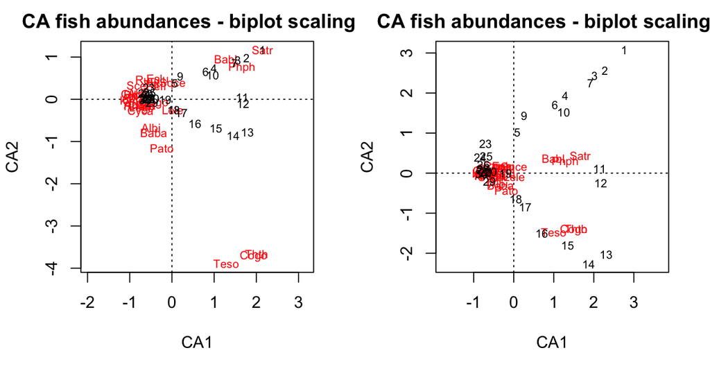

```r
par(mfrow = c(1, 2))
plot(spe_ca, scaling = 1, main = "CA fish abundances - biplot scaling 1")
plot(spe_ca, scaling = 2, main = "CA fish abundances - biplot scaling 2")
```

```r
require('viridis')
palette(viridis(8))
par(mar = c(4, 4, 0.9, 0.5) + .1, mfrow = c(2, 2))
with(spe, tmp <- ordisurf(spe_ca ~ Satr, bubble = 3,
                          family = quasipoisson, knots = 2, col = 6,
                          display = "sites", main = "Satr"))
abline(h = 0, v = 0, lty = 3)
```

```r
with(spe, tmp <- ordisurf(spe_ca ~ Scer, bubble = 3,
                          family = quasipoisson, knots = 2, col = 6,
                          display = "sites", main = "Scer"))
abline(h = 0, v = 0, lty = 3)
```

```r
with(spe, tmp <- ordisurf(spe_ca ~ Teso, bubble = 3,
                          family = quasipoisson, knots = 2, col = 6,
                          display = "sites", main = "Teso"))
abline(h = 0, v = 0, lty = 3)
```

```r
with(spe, tmp <- ordisurf(spe_ca ~ Cogo, bubble = 3,
                          family = quasipoisson, knots = 2, col = 6,
                          display = "sites", main = "Cogo"))
abline(h = 0, v = 0, lty = 3)
```

```r
# A posteriori projection of environmental variables in a CA
# The last plot produced (CA scaling 2) must be active

env <- read.csv("Num_Ecol_R_book_ed1/DoubsEnv.csv")
env <- dplyr::select(env, -1)
env <- dplyr::slice(env, -8)

(spe_ca_env <- envfit(spe_ca, env, scaling = 2)) # Scaling 2 is default
```

```
***VECTORS

         CA1      CA2     r2 Pr(>r)
dfs -0.94799 -0.31830 0.6892  0.001 ***
alt  0.81159  0.58423 0.8078  0.001 ***
slo  0.73753  0.67531 0.2976  0.004 **
flo -0.92837 -0.37166 0.4440  0.001 ***
pH   0.50723 -0.86181 0.0908  0.220
har -0.71728 -0.69678 0.4722  0.002 **
pho -0.99897  0.04533 0.1757  0.073 .
nit -0.94906 -0.31511 0.4510  0.001 ***
amm -0.97495  0.22241 0.1762  0.081 .
oxy  0.93352 -0.35854 0.6263  0.001 ***
bod -0.94094  0.33857 0.2237  0.040 *
---
Signif. codes:  0 ‘***’ 0.001 ‘**’ 0.01 ‘*’ 0.05 ‘.’ 0.1 ‘ ’ 1
Permutation: free
Number of permutations: 999
```

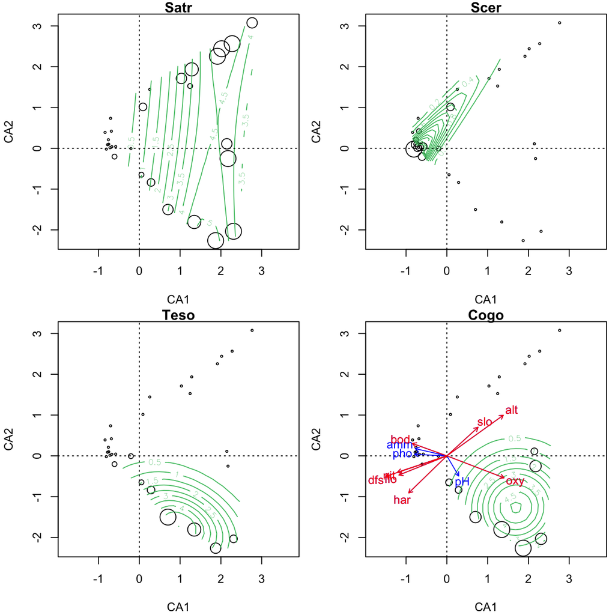

```r
plot(spe_ca_env)
# Plot significant variables with a different colour
plot(spe_ca_env, p.max = 0.05, col = "red")
```

### Questions

1. How would you explain the patterns seen in the four panels of the above figure?
2. Apply approaches taken from the analysis shown immediately above to these datasets:
   1. [bird communities along elevation gradient in Yushan Mountain, Taiwan](https://www.davidzeleny.net/anadat-r/doku.php/en:data:ybirds);
   2. [alpine plant communities in Aravo, France](https://www.davidzeleny.net/anadat-r/doku.php/en:data:aravo).
3. Discuss the patterns observed, and explain the ordination diagrams with particular reference to how the species are influenced by the major environmental drivers.

Submit an R script wherein you provide answers to these questions by no later than 17:00 on Friday 16 July 2021.